# M303: Marketing Research

## M303 Marketing Research

M303: Marketing Research

Meeting 6: Introduction to Survey Methods

Dr. Koray Cosguner

## Last Class – Quiz

1. F All behaviors can be observed.
2. F In order to answer “why” questions, one can use observation rather than questioning.
3. T Cognitive phenomena can’t be observed.
4. T A systematic process of recording behaviors without normally communicating with the people involved is called observation.
5. T One can use qualitative methods in order to get a better idea about things that can’t be directly observed and/or measured.
6. F Nondirective interviews are especially effective with busy executives, technical experts, and thought leaders.
7. F In semi-structured or focused interviews, the respondent is given the maximum freedom to respond.
8. F In symbolic analysis, the interviewer step by step probes to the question of interest.
9. T When direct questions fail, one might use projective techniques.

## This Class

01

Preliminary stages of marketing research

Problem formulation  
Research design

02

Data collection

- **Secondary data**
- **Primary data**: survey methods · **we are here today**
- **Sampling**

03

Data analysis & recommendation

Fundamentals of data analysis  
Hypothesis testing  
Correlation and regression, count and choice models

## Learning Objectives

- You should be able to
  - Learn advantages and issues of/with surveys
  - Understand different types of surveys and pros and cons of each type

## What Information Can Be Acquired From Surveys?

Knowledge

Consumers’ awareness and knowledge about your products.

Attitudes

Consumers’ perceptions about your products and services

Assessments

Whether your marketing program/product etc. is favorable or not.

Reasons Behind Decisions

Measuring the relationship between actions & needs, desires, preferences, motivations and goals in order to answer the “why” questions.

Demographics & Lifestyles

Age, gender, marital status, income, employment status, hobbies etc.

Social Contacts and Interactions

Families, friends, social groups, memberships

## Why to Use Survey Research?

- Surveys are the overwhelming choice of researchers for collecting quantitative primary data.
- Surveys have many advantages such as
  - Cost & speed
  - Accuracy
  - Efficiency
  - Flexibility
- Qualitative and observational methods are more likely to be used to improve and/or supplement the survey methods rather than to take its place.

## What Are the Potential Issues in Surveys?

In order to obtain meaningful results:

- Population has to be defined correctly
- Sample should be representative of the population
- Respondents selected are able and willing to cooperate
- Respondents have the knowledge, opinions, attitudes, or facts required
- Questions are understood by the respondents
- Interviewer correctly understands and records the responses

## What Are the Types of Surveys?

Surveys

Telephone  
Interviews

Self-Administered  
Surveys

Personal  
Interviews

- Door-to-door interviewing
- Executive interviewing
- Mall intercept surveys
- Purchase intercept technique
- Omnibus surveys

Combination of  
Survey Methods

## Types of Surveys: Telephone Interviews

- Telephone interviewing is the dominant method for obtaining information from large samples.
- Selecting telephone numbers
  - **Pre-specified list**: a membership roster, a customer list, or numbers bought from a supplier. Useful for a selected group, uncommon in marketing research.
  - **A directory**: the phone company’s listings. About 25% of US households are unlisted and likely differ from the rest, so this builds in bias.
  - **Random dialing procedure**: mitigates that bias
    - **Random digit dialing**: generate all ten digits at random. Most turn out not to exist, and the sample may miss your market.
    - **Systematic random digit dialing (SRDD)**: draw a working area code and prefix first, then randomize only the last digits. Far fewer dead numbers.
    - **Plus-one dialing**: take a listed number and add one. 314-327-2989 → you call 314-327-2990.

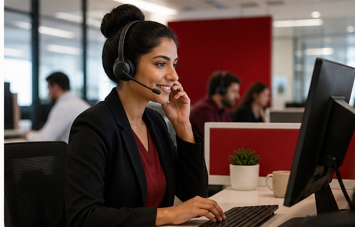

## What Are the Pros of Telephone Interviews?

- More interviews can be conducted in a given time
- Travelling time is saved
- More hours of the day/week are productive
- Ease of call backs at lower cost (WATS, wide area telephone service: unlimited calls to a given zone in the US or Canada)

## What Are the Cons of Telephone Interviews?

- Inability to employ visual aids or complex tasks
- Interviewer must rely solely on verbal cues to judge the reaction and understanding of respondents
- Can’t be longer than 5 to 10 min. or the respondent gets bored
- Amount of data that can be collected is relatively less
- A capable interviewer is essential
- Potential for sample bias
  - No phone, unlisted phone or mobile phones
  - Nonresponse: most people contacted never take part, and those who do may differ from those who do not

## Types of Surveys: Self-Administered Surveys

- No interviewer involved
- Survey is either emailed, mailed, faxed or handed

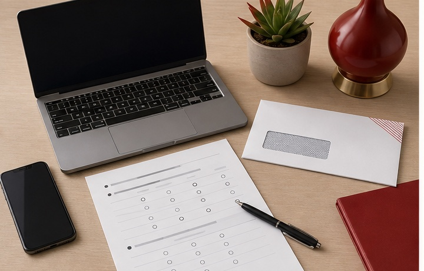

## How to Conduct Self-Administered Surveys?

- Method of reaching should be determined
- Cover letter should be prepared
- Questionnaire length, content, layout, color, and format should be chosen
- Incentives might be given to increase the response rates
- The return of the responses should be made easy for the respondent

## What Is the Response Rate in Self-Administered Surveys?

- Low survey quality ⇒ low response rate ⇒ sample bias
- **Ex:** If you contacted 1,000 participants and the response rate is 5%, then what is the number of complete surveys?

Answer

1,000 participants contacted × 5% = **50 complete surveys**

## What Are the Factors Affecting the Response Rate?

- Perceived amount of work required
  - Long surveys → low response rate
  - Difficult surveys → low response rate
- Intrinsic interest in the topic
  - Low interest topics → low response rate
- Level of motivation
  - Monetary incentives → high response rate
- Characteristics of the sample

## What Are the Pros of Self-Administered Surveys?

- Lower cost
- Larger samples
- Time savings
- No interviewer biases
- Survey answered at respondents’ discretion

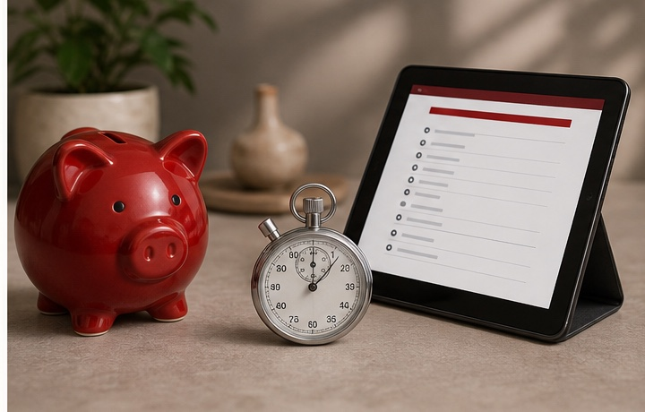

## What Are the Cons of Self-Administered Surveys?

- The absence of an interviewer causes limited control on
  - Understanding the identity of respondents
  - Whom the respondent might consult for help in understanding the questions
  - The speed of the response
  - The order in which the questions are exposed and answered

## Types of Surveys: Personal Interviews

- Face-to-face survey method.
- Personal interview process is characterized by the interaction of 4 entities.

Researcher

Interviewer

Respondent

Interview  
Environment

## What Are the Types of Personal Interviews?

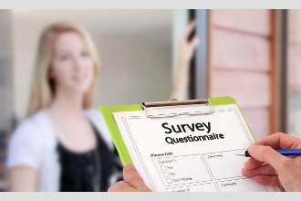

Door to Door Interviewing

Interviews with respondents in their home

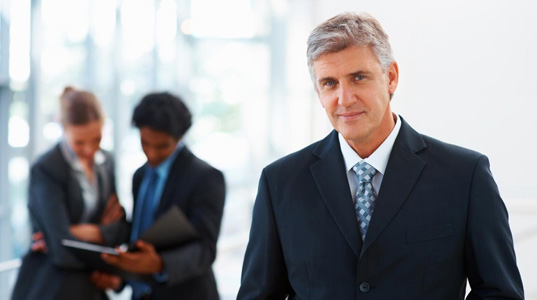

Executive Interviewing

Interviews with business people at their office

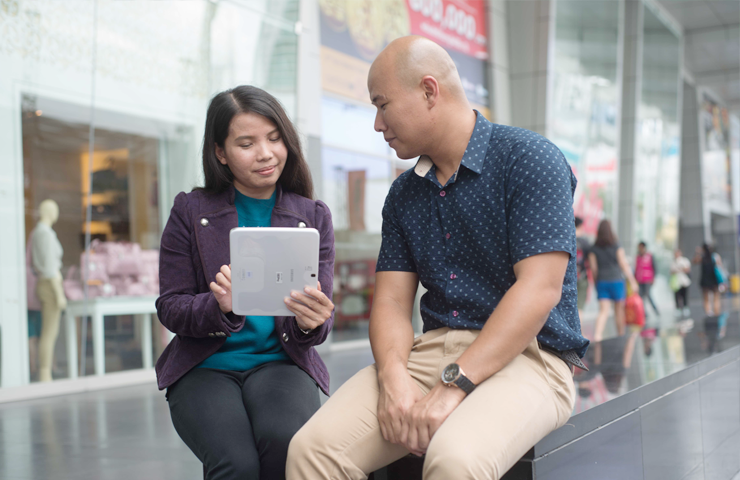

Mall Intercept Interviews

Interviews with mall shoppers in shopping centers

## What Are the Types of Personal Interviews? (Contd.)

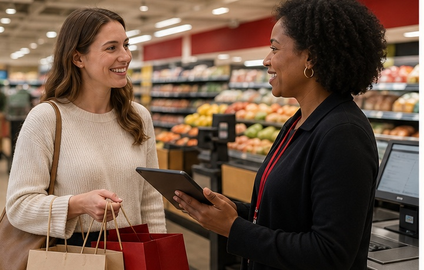

Purchase Intercept Technique

Interviews with customers after observing them making purchases in stores

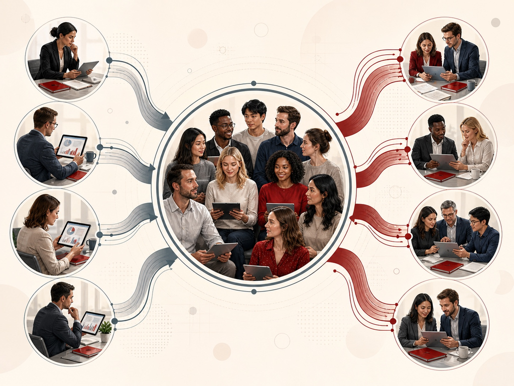

Omnibus Surveys

A research firm combines questions from several clients into one regularly scheduled survey. Each client receives the results for its own questions.

## Pros and Cons of Personal Interview Types

| Interview Type | Advantages and Disadvantages |
| --- | --- |
| Door-to-door interviewing | −Relatively expensive +Comfortable environment for respondents +Extensive illustrations and in-depth explanations are possible +Viable way for in-home product tests |
| Executive interviewing | −Very expensive to set up meetings −The interviewer has to go to the respondent’s office −Long waiting time and cancellations are common |
| Mall intercept surveys | +Relatively lower costs −Respondents may not be a representative sample |

## Pros and Cons of Personal Interview Types (Contd.)

| Interview Type | Advantages and Disadvantages |
| --- | --- |
| Purchase intercept technique | +Respondents’ buying experiences are salient −Respondents may not be a representative sample |
| Omnibus surveys | +Low costs, clients share costs +Good solution if questions are limited and more standard +Suitable for tracking periodically and before-after studies |

## What Are the Pros of Personal Interviews?

- Can arouse and keep interest
- Ask complex questions with the help of visual and other aids
- Clarify misunderstandings
- High degree of flexibility: the interviewer can branch on the last answer. Say yes to “have you heard of this agency?” and two follow-ups come next; say no and they are skipped.
- Good for neutral questions

## What Are the Cons of Personal Interviews?

- Respondent and interviewer biases
- Lack of respondent anonymity
- Embarrassing/personal questions
- Time requirements
- Cost per completed interview is high
- Trained interviewers (geographically near the sample) are required

## When Should You Use Personal Interviews?

- Large information per respondent
- Complex questions
- Require tasks
- Product test
- No other choices
  - No phone number
  - No mailing address
  - No email address

## Types of Surveys: Combination of Survey Methods

- Each survey method has different pros and cons, therefore combination of survey methods can retain the best features while minimizing the limitations.
- **Example:** Telephone pre-notification approach

## What Is Telephone Pre-Notification?

Call to ask permission before mail survey

- **Advantages**
  - Gain agreements
  - The respondent is serious about the cooperation
- **Disadvantages**
  - Obtain both phone number and mailing address of the respondents.

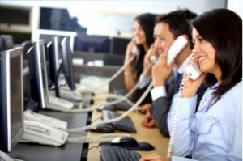

Agreement ↓

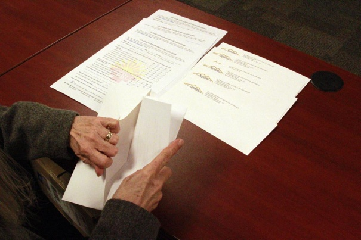

## What Is the Lockbox Approach?

- Mail a box with a lock – the questionnaire and a gift are locked inside – a combination of lock/pin will be given right before the interview.
- Due to the created curiosity, the response rates can be as high as 50% to 70%.

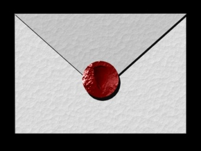

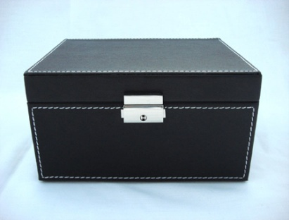

[figure not shown]

[figure not shown]

## How to Choose a Survey Method?

- **Type of population** – reading and writing skills, motivation to cooperate
- **Sampling** – how to draw a representative sample
- **Questions** – complex vs. easy, general vs. sensitive
- Response rates
- Costs
- Available facilities and availability of trained interviewers
- Duration of data collection

## Sum Up

- Surveys
  - Pros
  - Limitations
- Types of surveys and their pros and cons
  - Telephone interviews
  - Self-administered surveys
  - Personal interviews
    - Door-to-door, executive, mall intercept, purchase intercept, omnibus
- Combination of survey methods

## Today’s Class: Quiz

1. T Surveys can be used to understand consumers’ perceptions about products and services.
2. T Surveys can be used to collect information about consumer demographics and lifestyles.
3. T Four advantages of surveys are their low cost, high accuracy, efficiency and flexibility.
4. F Qualitative methods can easily be used to replace surveys.
5. T In order to obtain meaningful results from a survey, one has to define the population of interest correctly.
6. T In a telephone survey, one might use phone directories to select the telephone numbers to call.
7. F The cost of telephone interviews is typically higher than face to face interviews.
8. T If one wants to employ visual aids or complex tasks, face to face interviews become the best survey method.

## Today’s Class: Quiz (Contd.)

1. T In telephone interviews, the interviewer must rely solely on verbal cues to judge the reaction and understanding of respondents.
2. T If you contacted 1,000 participants and the response rate is 10%, then the number of complete surveys should be 100.
3. T The response rate in a self-administered survey decreases as the survey becomes longer.
4. F Door to door interviewing refers to interviews with mall shoppers in shopping centers.
5. T In an omnibus survey, multiple clients have sections of questions in the survey; this way the cost of conducting the survey is shared among these clients.
6. F Among the personal interview methods, the most costly one is the mall intercept surveys.
7. T If you do not have any contact information such as phone numbers, mailing and email addresses, personal interviews become the feasible survey method.
8. T In Telephone Pre-notification method, you call to ask the respondent’s permission before mailing the survey.

## Next Class

Meeting 7 · Application Workshop: Research Design, Secondary Data, and Qualitative Methods

EXAM 1

September 17, right after the workshop. It covers everything from the start of the course.